# R Notebook

Question 3 Recall the putts data from class. The R notebook posted from December 2 presents two models: a logistic model and a “physical” model. Suppose we wished to incorporate the following prior expert opinion into our models: . My best guess for the probability of making a 5-foot putt is 52.5%; however, there is a 95% chance that this probability is below 71.6%. . My best guess for the probability of making a 10-foot putt is 27.8%; however, there is a 95% chance that this probability is below 40.8%.

1. Re-fit both models incorporating this prior information. Plot the data with 95% posterior credible bands for the probabilities of successful putts. (You do not need to provide posterior predictive bands.)

```r
setwd("C:/Users/Palma/Desktop/MS STATS/Year2 Sem1/Bayesian/FinalTakehome")
library(rstan)
load("putts.RData")
set.seed(1202)
attach(putts)
putts
```

| distance | n | y |
| --- | --- | --- |
| 2 | 1443 | 1346 |
| 3 | 694 | 577 |
| 4 | 455 | 337 |
| 5 | 353 | 208 |
| 6 | 272 | 149 |
| 7 | 256 | 136 |
| 8 | 240 | 111 |
| 9 | 217 | 69 |
| 10 | 200 | 67 |
| 11 | 237 | 75 |

[output cut: 9 more lines]

Let’s try to fit a simple logistic model to these data:
$$\begin{split}
& y_x \overset{ind}{\sim} Binomial(n_x,p_x) \\
& \ln\left(\frac{p_x}{1-p_x}\right) = \beta_0+\beta_1(x-7),\quad x\in\{2,3,\ldots,20\}.
\end{split}$$

```r
getthetaprior <- function(bg,hi){
# Interpreting bg as the mode of a Beta(a,b) distribution,
# we determine that b = (a-1+bg(2-a))/bg. Furthermore, we want
# the 95th percentile of this beta distribution to be hi.
f <- function(a) { pbeta(hi,a,(a-1-bg*(a-2))/bg)-.95 }
a <- uniroot(f,c(1,3000))$root
b <- (a-1-bg*(a-2))/bg
return(c(a,b))
}
  ab5 <- getthetaprior(.525,.716)
  ab10 <- getthetaprior(.278,.408)
```

Based on expert opinion, our priors for $\theta_{5}$ and $\theta_{10}$ are as follows:

- $\theta_{5} \sim Beta(8.74,8.01)$.
- $\theta_{10} \sim Beta(12.1,29.84)$.

How would we use these priors on different $\theta$s to induce priors on $\beta_0$ and $\beta_1$? For each simulated $\left(\theta_{10}\theta_{5}\right)$ pair, we have:

$$\begin{split}
& \begin{pmatrix} F^{-1}(\theta_{5}) \\ F^{-1}(\theta_{10}) \end{pmatrix}
= \begin{pmatrix}1 & -2 \\ 1 & 3\end{pmatrix}\begin{pmatrix}\beta_0 \\ \beta_1\end{pmatrix} \\
& \implies
\begin{pmatrix}\beta_0 \\ \beta_1\end{pmatrix} = \begin{pmatrix}1 & -2 \\ 1 & 3\end{pmatrix}^{-1}\begin{pmatrix} F^{-1}(\theta_{5}) \\ F^{-1}(\theta_{10}) \end{pmatrix}
= \begin{pmatrix}.6 & .4 \\ -.2 & .2\end{pmatrix}\begin{pmatrix} F^{-1}(\theta_{5}) \\ F^{-1}(\theta_{10}) \end{pmatrix}
= \begin{pmatrix}.6\,F^{-1}(\theta_{5}) + .4\,F^{-1}(\theta_{10}) \\ -.2\,F^{-1}(\theta_{5}) + .2\,F^{-1}(\theta_{10})\end{pmatrix}
\end{split}$$

```r
solve(rbind(c(1,-2),c(1,3)))
```

```
     [,1] [,2]
[1,]  0.6  0.4
[2,] -0.2  0.2
```

```r
### Model 1 - "Logistic model"
set.seed(505)
mod1code <- '
  data{
    int<lower=1>         n[19];
    int<lower=0>         y[19];
    real<lower=0>        x[19];
  }
  parameters{
   real<lower=0,upper=1> theta5;  //
  real<lower=0,upper=1> theta10;  //
  }
 transformed parameters{
  real<lower=0,upper=1> p[19];
  real b0;
  real b1;
  // For logistic regression, Finv is the logit function
  b0 = .6*logit(theta5)+.4*logit(theta10);
  b1 = -.2*logit(theta5)+.2*logit(theta10);

    for(i in 1:19){
      p[i] = inv_logit(b0+b1*(x[i]-7));
    }
  }
  model{
  theta5 ~ beta(8.744599,8.007018);
  theta10 ~ beta(12.10458,29.83995);
for(i in 1:19){
      y[i] ~ binomial(n[i],p[i]);
  }
  }
'
mod1dat <- with(putts,list(n=n,y=y,x=distance))
mod1 <- stan(model_code=mod1code, data=mod1dat)
```

[output not shown]

[output cut: 17 more lines]

[output not shown]

```r
print(mod1,digits=5)
```

```
Inference for Stan model: b36b0a5bf1d518e09d327419d60610fc.
4 chains, each with iter=2000; warmup=1000; thin=1;
post-warmup draws per chain=1000, total post-warmup draws=4000.

               mean se_mean      sd        2.5%         25%         50%         75%       97.5% n_eff
theta5      0.71992 0.00014 0.00684     0.70661     0.71526     0.71981     0.72434     0.73367  2356
theta10     0.41664 0.00018 0.00857     0.39943     0.41090     0.41675     0.42212     0.43381  2286
p[1]        0.84711 0.00011 0.00605     0.83485     0.84314     0.84718     0.85130     0.85861  2826
p[2]        0.81094 0.00012 0.00641     0.79824     0.80666     0.81092     0.81533     0.82318  2684
p[3]        0.76855 0.00013 0.00666     0.75554     0.76410     0.76851     0.77293     0.78160  2523
p[4]        0.71992 0.00014 0.00684     0.70661     0.71526     0.71981     0.72434     0.73367  2356
p[5]        0.66551 0.00015 0.00699     0.65199     0.66078     0.66544     0.67002     0.67980  2211
p[6]        0.60631 0.00016 0.00722     0.59230     0.60133     0.60631     0.61102     0.62116  2122
p[7]        0.54381 0.00016 0.00758     0.52881     0.53856     0.54379     0.54873     0.55905  2111
p[8]        0.47990 0.00017 0.00806     0.46421     0.47449     0.48000     0.48512     0.49612  2174
p[9]        0.41664 0.00018 0.00857     0.39943     0.41090     0.41675     0.42212     0.43381  2286
p[10]       0.35603 0.00018 0.00897     0.33820     0.35013     0.35619     0.36188     0.37399  2419
p[11]       0.29971 0.00018 0.00917     0.28177     0.29370     0.29996     0.30575     0.31801  2550
p[12]       0.24887 0.00018 0.00912     0.23098     0.24284     0.24912     0.25496     0.26695  2669
p[13]       0.20415 0.00017 0.00881     0.18673     0.19825     0.20425     0.21004     0.22167  2771
p[14]       0.16569 0.00015 0.00828     0.14960     0.16011     0.16568     0.17123     0.18219  2856
p[15]       0.13328 0.00014 0.00760     0.11857     0.12807     0.13325     0.13833     0.14844  2927
p[16]       0.10640 0.00012 0.00683     0.09310     0.10182     0.10638     0.11090     0.12016  2985
p[17]       0.08442 0.00011 0.00603     0.07271     0.08039     0.08435     0.08836     0.09668  3033
p[18]       0.06665 0.00009 0.00524     0.05661     0.06311     0.06654     0.07009     0.07739  3073
p[19]       0.05240 0.00008 0.00450     0.04376     0.04941     0.05226     0.05533     0.06170  3106
b0          0.43191 0.00066 0.03027     0.37349     0.41102     0.43184     0.45162     0.49448  2122
b1         -0.25620 0.00011 0.00673    -0.26957    -0.26073    -0.25632    -0.25163    -0.24289  3435
lp__    -3060.90927 0.02121 0.95847 -3063.46403 -3061.26632 -3060.60219 -3060.21742 -3059.96778  2043
           Rhat
theta5  0.99961
theta10 0.99924
p[1]    1.00007
p[2]    0.99996
p[3]    0.99980
p[4]    0.99961
p[5]    0.99939
p[6]    0.99921
p[7]    0.99912
p[8]    0.99915
p[9]    0.99924
p[10]   0.99937
p[11]   0.99950
p[12]   0.99962
p[13]   0.99971
p[14]   0.99979
p[15]   0.99986
p[16]   0.99992
p[17]   0.99996
p[18]   1.00000
p[19]   1.00004
b0      0.99921
b1      1.00029
lp__    1.00016

Samples were drawn using NUTS(diag_e) at Mon Dec 12 18:13:32 2016.
For each parameter, n_eff is a crude measure of effective sample size,
and Rhat is the potential scale reduction factor on split chains (at
convergence, Rhat=1).
```

```r
# Print and plot the results
mod1
```

```
Inference for Stan model: b36b0a5bf1d518e09d327419d60610fc.
4 chains, each with iter=2000; warmup=1000; thin=1;
post-warmup draws per chain=1000, total post-warmup draws=4000.

            mean se_mean   sd     2.5%      25%      50%      75%    97.5% n_eff Rhat
theta5      0.72    0.00 0.01     0.71     0.72     0.72     0.72     0.73  2356    1
theta10     0.42    0.00 0.01     0.40     0.41     0.42     0.42     0.43  2286    1
p[1]        0.85    0.00 0.01     0.83     0.84     0.85     0.85     0.86  2826    1
p[2]        0.81    0.00 0.01     0.80     0.81     0.81     0.82     0.82  2684    1
p[3]        0.77    0.00 0.01     0.76     0.76     0.77     0.77     0.78  2523    1
p[4]        0.72    0.00 0.01     0.71     0.72     0.72     0.72     0.73  2356    1
p[5]        0.67    0.00 0.01     0.65     0.66     0.67     0.67     0.68  2211    1
p[6]        0.61    0.00 0.01     0.59     0.60     0.61     0.61     0.62  2122    1
p[7]        0.54    0.00 0.01     0.53     0.54     0.54     0.55     0.56  2111    1
p[8]        0.48    0.00 0.01     0.46     0.47     0.48     0.49     0.50  2174    1
p[9]        0.42    0.00 0.01     0.40     0.41     0.42     0.42     0.43  2286    1
p[10]       0.36    0.00 0.01     0.34     0.35     0.36     0.36     0.37  2419    1
p[11]       0.30    0.00 0.01     0.28     0.29     0.30     0.31     0.32  2550    1
p[12]       0.25    0.00 0.01     0.23     0.24     0.25     0.25     0.27  2669    1
p[13]       0.20    0.00 0.01     0.19     0.20     0.20     0.21     0.22  2771    1
p[14]       0.17    0.00 0.01     0.15     0.16     0.17     0.17     0.18  2856    1
p[15]       0.13    0.00 0.01     0.12     0.13     0.13     0.14     0.15  2927    1
p[16]       0.11    0.00 0.01     0.09     0.10     0.11     0.11     0.12  2985    1
p[17]       0.08    0.00 0.01     0.07     0.08     0.08     0.09     0.10  3033    1
p[18]       0.07    0.00 0.01     0.06     0.06     0.07     0.07     0.08  3073    1
p[19]       0.05    0.00 0.00     0.04     0.05     0.05     0.06     0.06  3106    1
b0          0.43    0.00 0.03     0.37     0.41     0.43     0.45     0.49  2122    1
b1         -0.26    0.00 0.01    -0.27    -0.26    -0.26    -0.25    -0.24  3435    1
lp__    -3060.91    0.02 0.96 -3063.46 -3061.27 -3060.60 -3060.22 -3059.97  2043    1

Samples were drawn using NUTS(diag_e) at Mon Dec 12 18:13:32 2016.
For each parameter, n_eff is a crude measure of effective sample size,
and Rhat is the potential scale reduction factor on split chains (at
convergence, Rhat=1).
```

```r
p <- extract(mod1)$p
with(putts,plot(y/n~distance,pch=16,
                main="Logistic Model Fit",
                ylim=c(0,1),bty="l",
                xlab="Distance (ft)",
                ylab="Proportion successful"))
lines(2:20,colMeans(p),lwd=2)
```

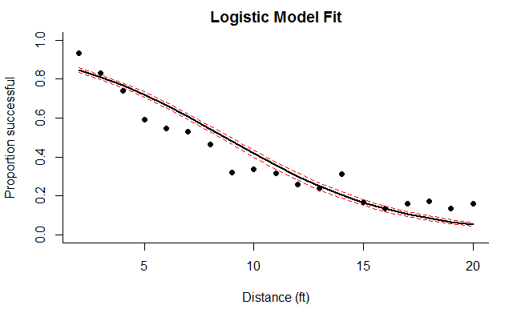

```r
lines(2:20,apply(p,2,quantile,.025),col="red",lty=2)
lines(2:20,apply(p,2,quantile,.975),col="red",lty=2)
```

$$p_x = P\left[|\theta|\leq \sin^{-1}\left(\frac{R-r}{x}\right)\right]
=P\left[|Z|\leq\frac{1}{\sigma}\sin^{-1}\left(\frac{R-r}{x}\right)\right]
=2\Phi\left(\frac{1}{\sigma}\sin^{-1}\left(\frac{R-r}{x}\right)\right)-1,$$
where $Z$ is a standard normal random variable and $\Phi$ is the CDF of the standard normal distribution.

##### Prior on $\sigma$

Our initial prior distribution on the parameter $\sigma$ is $\sigma \sim Uniform\left(0,\frac{\pi}{6}\right)$ . Using expert inofrmation My best guess for the probability of making a 10-foot putt is 27.8%; however, there is a 95% chance that this probability is below 40.8%. To incorporate prior information about $\sigma$ we can manipulate this information and obtain the result below;

$$P\left[2\Phi\left(\frac{1}{\sigma}\sin^{-1}\left(\frac{R-r}{x}\right)\right)-1 \leq.408\right]=0.95$$

We solve and obtain an expression for $\sigma$

$$P\left[\frac{1}{\sigma}\leq \frac{\Phi^{-1}(0.704)}{\sin^{-1}\left(\frac{R-r}{10}\right)} \right]=0.95$$

```r
##compute sigma95
sigma95= 1/(qnorm(.5*(0.408+1))*1/(asin(0.1*(4.25/24-1.68/24))))
```

$$\quad \implies \quad P(\sigma >0.02) = .95.$$
$$\quad \implies \quad 1-F_\sigma(sigma95) = .95.$$

Thus since the prior of $\sigma$ is a uniform distribution we can obtain apporpriate bounds on the uniform distribution, so our informative prior distirbution on $\sigma$ is $Uniform (0,0.3996)$. That is the distance of b-a of a Uniform (a,b) distribution.

```r
### Model 2 - "Physical model"
set.seed(507)
mod2code <- '
  data{
    real<lower=0>        smallr;
    real<lower=smallr>   bigR;
    int<lower=1>         n[19];
    int<lower=0>         y[19];
    real<lower=0>        x[19];
  }
  parameters{
    real<lower=0> sigma;
  }
  transformed parameters{
    real<lower=0,upper=1> p[19];
    for(i in 1:19){
      p[i] = 2*Phi(asin((bigR-smallr)/x[i])/sigma) - 1;
    }
  }
  model{
    sigma ~ uniform(0,.3996);
    for(i in 1:19){
      y[i] ~ binomial(n[i],p[i]);
    }
  }
'
smallr <- 1.68/24   ## A reg golf ball has diameter 1.68 in; we convert to ft
bigR <- 4.25/24     ## A reg golf hole has diameter 4.25 in; we convert to feet
mod2dat <- with(putts,list(smallr=smallr,bigR=bigR,y=y,n=n,x=distance))
mod2 <- stan(model_code=mod2code,data=mod2dat)
```

[output not shown]

[output cut: 14 more lines]

[output not shown]

```r
print(mod2)
```

```
Inference for Stan model: 262763cb6f2fc7a501460c6793e01a54.
4 chains, each with iter=2000; warmup=1000; thin=1;
post-warmup draws per chain=1000, total post-warmup draws=4000.

          mean se_mean   sd     2.5%      25%      50%      75%    97.5% n_eff Rhat
sigma     0.03    0.00 0.00     0.03     0.03     0.03     0.03     0.03  2888    1
p[1]      0.96    0.00 0.00     0.95     0.95     0.96     0.96     0.96  2879    1
p[2]      0.82    0.00 0.01     0.81     0.82     0.82     0.82     0.83  2888    1
p[3]      0.68    0.00 0.01     0.67     0.68     0.68     0.69     0.70  2891    1
p[4]      0.58    0.00 0.01     0.57     0.57     0.58     0.58     0.59  2893    1
p[5]      0.50    0.00 0.01     0.48     0.49     0.50     0.50     0.51  2894    1
p[6]      0.43    0.00 0.01     0.42     0.43     0.43     0.44     0.45  2894    1
p[7]      0.38    0.00 0.01     0.37     0.38     0.38     0.39     0.39  2894    1
p[8]      0.34    0.00 0.00     0.34     0.34     0.34     0.35     0.35  2895    1
p[9]      0.31    0.00 0.00     0.30     0.31     0.31     0.31     0.32  2895    1
p[10]     0.29    0.00 0.00     0.28     0.28     0.29     0.29     0.29  2895    1
p[11]     0.26    0.00 0.00     0.26     0.26     0.26     0.26     0.27  2895    1
p[12]     0.24    0.00 0.00     0.24     0.24     0.24     0.24     0.25  2895    1
p[13]     0.23    0.00 0.00     0.22     0.22     0.23     0.23     0.23  2895    1
p[14]     0.21    0.00 0.00     0.21     0.21     0.21     0.21     0.22  2895    1
p[15]     0.20    0.00 0.00     0.19     0.20     0.20     0.20     0.20  2895    1
p[16]     0.19    0.00 0.00     0.18     0.18     0.19     0.19     0.19  2895    1
p[17]     0.18    0.00 0.00     0.17     0.17     0.18     0.18     0.18  2895    1
p[18]     0.17    0.00 0.00     0.16     0.17     0.17     0.17     0.17  2895    1
p[19]     0.16    0.00 0.00     0.15     0.16     0.16     0.16     0.16  2895    1
lp__  -2926.75    0.02 0.68 -2928.72 -2926.91 -2926.49 -2926.31 -2926.26  1815    1

Samples were drawn using NUTS(diag_e) at Mon Dec 12 18:13:54 2016.
For each parameter, n_eff is a crude measure of effective sample size,
and Rhat is the potential scale reduction factor on split chains (at
convergence, Rhat=1).
```

```r
mod2
```

```
Inference for Stan model: 262763cb6f2fc7a501460c6793e01a54.
4 chains, each with iter=2000; warmup=1000; thin=1;
post-warmup draws per chain=1000, total post-warmup draws=4000.

          mean se_mean   sd     2.5%      25%      50%      75%    97.5% n_eff Rhat
sigma     0.03    0.00 0.00     0.03     0.03     0.03     0.03     0.03  2888    1
p[1]      0.96    0.00 0.00     0.95     0.95     0.96     0.96     0.96  2879    1
p[2]      0.82    0.00 0.01     0.81     0.82     0.82     0.82     0.83  2888    1
p[3]      0.68    0.00 0.01     0.67     0.68     0.68     0.69     0.70  2891    1
p[4]      0.58    0.00 0.01     0.57     0.57     0.58     0.58     0.59  2893    1
p[5]      0.50    0.00 0.01     0.48     0.49     0.50     0.50     0.51  2894    1
p[6]      0.43    0.00 0.01     0.42     0.43     0.43     0.44     0.45  2894    1
p[7]      0.38    0.00 0.01     0.37     0.38     0.38     0.39     0.39  2894    1
p[8]      0.34    0.00 0.00     0.34     0.34     0.34     0.35     0.35  2895    1
p[9]      0.31    0.00 0.00     0.30     0.31     0.31     0.31     0.32  2895    1
p[10]     0.29    0.00 0.00     0.28     0.28     0.29     0.29     0.29  2895    1
p[11]     0.26    0.00 0.00     0.26     0.26     0.26     0.26     0.27  2895    1
p[12]     0.24    0.00 0.00     0.24     0.24     0.24     0.24     0.25  2895    1
p[13]     0.23    0.00 0.00     0.22     0.22     0.23     0.23     0.23  2895    1
p[14]     0.21    0.00 0.00     0.21     0.21     0.21     0.21     0.22  2895    1
p[15]     0.20    0.00 0.00     0.19     0.20     0.20     0.20     0.20  2895    1
p[16]     0.19    0.00 0.00     0.18     0.18     0.19     0.19     0.19  2895    1
p[17]     0.18    0.00 0.00     0.17     0.17     0.18     0.18     0.18  2895    1
p[18]     0.17    0.00 0.00     0.16     0.17     0.17     0.17     0.17  2895    1
p[19]     0.16    0.00 0.00     0.15     0.16     0.16     0.16     0.16  2895    1
lp__  -2926.75    0.02 0.68 -2928.72 -2926.91 -2926.49 -2926.31 -2926.26  1815    1

Samples were drawn using NUTS(diag_e) at Mon Dec 12 18:13:54 2016.
For each parameter, n_eff is a crude measure of effective sample size,
and Rhat is the potential scale reduction factor on split chains (at
convergence, Rhat=1).
```

```r
p2 <- extract(mod2)$p
# Re-plot the earlier plot, and add the prediction intervals
with(putts,plot(y/n~distance,pch=16,
                main="Physical Model Fit",
                ylim=c(0,1),bty="l",
                xlab="Distance (ft)",
                ylab="Proportion successful"))
lines(2:20,colMeans(p2),lwd=2)
```

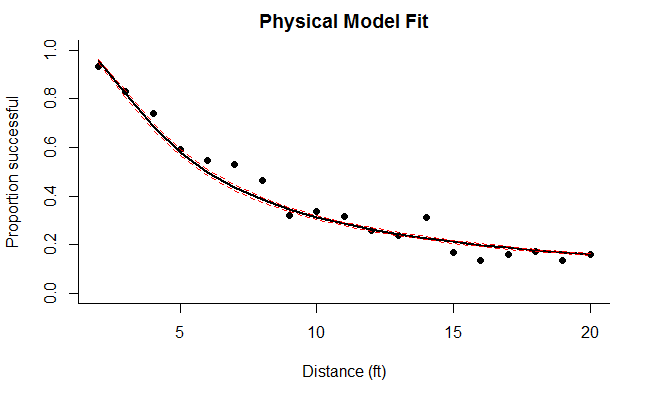

```r
lines(2:20,apply(p2,2,quantile,.025),col="red",lty=2)
lines(2:20,apply(p2,2,quantile,.975),col="red",lty=2)
```

2. Compare the fits of the two models using a Bayes factor. What do you conclude?

Code following this procedure for computing Bayes factors for each pair of models is given below.

```r
#useful functions
logit <- function(x) { log(x/(1-x)) }
invlogit <- function(x) { exp(x)/(1+exp(x)) }
# Generate large random samples of theta5 and theta10
th5 <- rbeta(10000,ab5[1],ab5[2])
th10 <- rbeta(10000,ab10[1],ab10[2])
## For each pair of thetas, generate the beta coefficients for each model
# Logistic
b01 <- .6*logit(th5)+.4*logit(th10)
b11 <- -.2*logit(th5)+.2*logit(th10)
# Physical  ################################
smallr <- 1.68/24   ## A reg golf ball has diameter 1.68 in; we convert to ft
bigR <- 4.25/24   ## A reg golf hole has diameter 4.25 in; we convert to feet
sigma<-0.03   ### mean of the posterior distribution of sigma
## Calculate ln f(y|beta,model) for each sampled beta for each model.
## Exponentiate these to obtain f(y|beta,model) for each beta for each model,
## and take their average to obtain an estimate of f(y|model) for each model.
# Logistic
putssuc<-putts$y/putts$n
thetas1 <- invlogit(b01 + b11 %*% t(distance-7))
logfyb1 <- log(thetas1) %*% putssuc + log(1-thetas1) %*% (1-putssuc) ###
fyb1 <- mean(exp(logfyb1))
# Physical
thetas2<-   2*pnorm(asin((bigR-smallr)/distance)/sigma)-1
logfyb2 <- log(thetas2) %*% putssuc + log(1-thetas2) %*% (1-putssuc) ##
fyb2 <- mean(exp(logfyb2))
## Estimate the Bayes factors for each pair of models:
BF12 <- fyb1/fyb2
BF12
```

```
[1] 0.3868563
```

Hence we can see that , given the expert’s prior information, the two models perform differently . It appears that the physical model performs better than the Logistic model.